# 聚类

Author: GONGGONGJOHN

## 背景描述

使用Datasets4Cluster.py生成了一些不同分布的二维数据，以生成的dataset1.csv为例，讲解不同的聚类方法及其有效性。

## 数据描述

| 变量名 | 变量含义 | 变量类型 | 变量取值范围 |
| --- | --- | --- | --- |
| （自变量1）$X_1$ | 数据点在X轴的坐标 | Continuous Variable | $\mathbb{R}^+$ |
| （自变量2）$X_2$ | 数据点在Y轴的坐标 | Continuous Variable | $\mathbb{R}^+$ |

## 问题

课件完成了四种聚类方法对dataset1聚类的不同效果。

在作业中对剩余数据集分别使用**层次聚类算法**、**Kmeans聚类算法**、**高斯混合模型**、**DBSCAN聚类算法**进行聚类，并且评价聚类结果的有效性。

应当有文字说明，谈谈你对不同聚类方法的理解，比较他们在不同数据集上的效果及产生的原因。

## 解决方案

### 层次聚类

正如其名字所指代，层次聚类是一种层级式的将相似物体聚合成簇的方法。它的主要思想是通过逐步构建一棵层次树来表示嵌套的组关系。 总的来说，层次聚类算法分为两种，分别为**聚合层次聚类（Agglomerative Hierarchical Clustering）**和**划分层次聚类（Divisive Hierarchical Clusstering）**， 这里我们主要使用前者。

在Python中，机器学习包Scikit-Learn专门封装了一套聚类的函数，通过直接调用并给定相关的参数，我们便可以得到相应的聚类结果。

下面我们分别对数据集2，3，4，5进行层次聚类。

首先我们将可视化聚类结果的过程封装为单独的函数，方便后续调用：

```python
import matplotlib.pyplot as plt
from scipy.cluster.hierarchy import dendrogram
import numpy as np

def draw(model, dataset):
    fig = plt.figure(figsize = [5,5])
    ax = fig.add_subplot(1,1,1)
    plt.xticks(())
    plt.yticks(())
    colors = ['blue','red','green','orange', 'black', 'cyan', 'magenta', 'aquamarine', 'brown', 'purple']

    k=0
    for i in model.labels_:
        plt.scatter(dataset[k][0], dataset[k][1], c=colors[i], marker='.',label=i)
        k+=1
    plt.show()


def plot_dendrogram(model, **kwargs):
    # Create linkage matrix and then plot the dendrogram

    # create the counts of samples under each node
    counts = np.zeros(model.children_.shape[0])
    n_samples = len(model.labels_)
    for i, merge in enumerate(model.children_):
        current_count = 0
        for child_idx in merge:
            if child_idx < n_samples:
                current_count += 1  # leaf node
            else:
                current_count += counts[child_idx - n_samples]
        counts[i] = current_count

    linkage_matrix = np.column_stack([model.children_, model.distances_, counts]).astype(float)

    # Plot the corresponding dendrogram
    dendrogram(linkage_matrix, **kwargs)
```

接下来我们分别对各个数据集进行层次聚类。

#### 数据集2

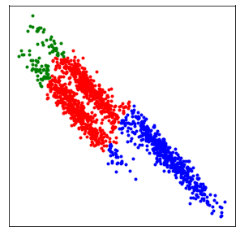

```python
import pandas as pd
from sklearn.cluster import AgglomerativeClustering

data2 = pd.read_csv('dataset2.csv')
data2_pure = data2.values[:, 1: 3]
model2_ac = AgglomerativeClustering(n_clusters=3, linkage='average').fit(data2_pure)
draw(model2_ac, data2_pure)
```

```
[1.11719245e-04 8.59763133e-04 1.08927186e-03 ... 1.67435366e+01
 2.45860600e+01 6.33651397e+01]
```

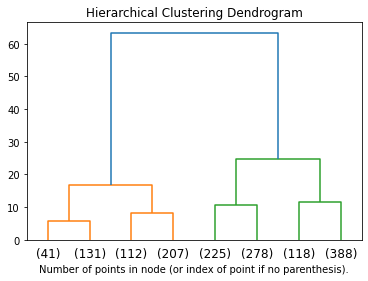

```python
clustering_data2 = AgglomerativeClustering(distance_threshold=0, n_clusters=None).fit(data2_pure)
print(clustering_data2.distances_)
plt.title("Hierarchical Clustering Dendrogram")
plot_dendrogram(clustering_data2, truncate_mode="level", p=2) #修改p可以展示不同的层数
plt.xlabel("Number of points in node (or index of point if no parenthesis).")
plt.show()
```

#### 数据集3

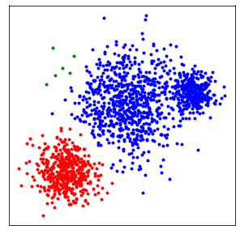

```python
data3 = pd.read_csv('dataset3.csv')
data3_pure = data3.values[:, 1: 3]
model3_ac = AgglomerativeClustering(n_clusters=3, linkage='average').fit(data3_pure)
draw(model3_ac, data3_pure)
```

```
[1.51167077e-03 1.69692323e-03 2.26825600e-03 ... 1.45086675e+01
 2.79598285e+01 5.25436230e+01]
```

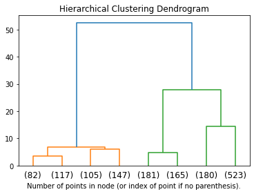

```python
clustering_data3 = AgglomerativeClustering(distance_threshold=0, n_clusters=None).fit(data3_pure)
print(clustering_data3.distances_)
plt.title("Hierarchical Clustering Dendrogram")
plot_dendrogram(clustering_data3, truncate_mode="level", p=2) #修改p可以展示不同的层数
plt.xlabel("Number of points in node (or index of point if no parenthesis).")
plt.show()
```

#### 数据集4

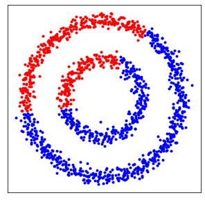

```python
data4 = pd.read_csv('dataset4.csv')
data4_pure = data4.values[:, 1: 3]
model4_ac = AgglomerativeClustering(n_clusters=2, linkage='average').fit(data4_pure)
draw(model4_ac, data4_pure)
```

```
[2.62879161e-04 3.77909951e-04 1.96245913e-03 ... 3.61348295e+01
 4.36873505e+01 5.75796715e+01]
```

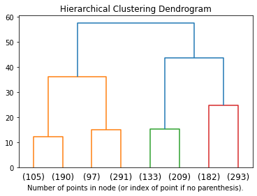

```python
clustering_data4 = AgglomerativeClustering(distance_threshold=0, n_clusters=None).fit(data4_pure)
print(clustering_data4.distances_)
plt.title("Hierarchical Clustering Dendrogram")
plot_dendrogram(clustering_data4, truncate_mode="level", p=2) #修改p可以展示不同的层数
plt.xlabel("Number of points in node (or index of point if no parenthesis).")
plt.show()
```

#### 数据集5

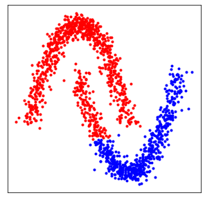

```python
data5 = pd.read_csv('dataset5.csv')
data5_pure = data5.values[:, 1: 3]
model5_ac = AgglomerativeClustering(n_clusters=2, linkage='average').fit(data5_pure)
draw(model5_ac, data5_pure)
```

```
[7.48344794e-04 8.19138671e-04 8.92862965e-04 ... 2.06063887e+01
 2.26421382e+01 5.45377275e+01]
```

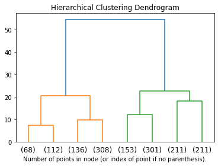

```python
clustering_data5 = AgglomerativeClustering(distance_threshold=0, n_clusters=None).fit(data5_pure)
print(clustering_data5.distances_)
plt.title("Hierarchical Clustering Dendrogram")
plot_dendrogram(clustering_data5, truncate_mode="level", p=2) #修改p可以展示不同的层数
plt.xlabel("Number of points in node (or index of point if no parenthesis).")
plt.show()
```

接下来我们对聚类的结果进行定量的评价。聚类的评价方法主要分为**外部聚类有效性**和**内部聚类有效性**，这里我们使用前者进行评价。

对于外部聚类有效性，我们通常会使用**熵**和**纯度**进行评价。 对于可能性矩阵，熵被定义为： $$ E = - \sum_i p_i \left(\sum_j \frac{p_{ij}}{p_i} \ln \frac{p_{ij}}{p_i} \right) $$， 纯度被定义为： $$ P = \sum_i p_i \left( \max_j \frac{p_{ij}}{p_i} \right) $$。

同样地，为了方便起见，我们将其单独封装为一个函数：

```python
import math

def cal_E(labels_,label, cluster, model_idx):
    n_sample = 1500 #样本数
    k4 = cluster #聚类类别数量
    pred_label = list(labels_) #预测结果
    real_label = [] #真实标签

    if model_idx == 3:
        for i in range(n_sample):
            if i < (2 / 10) * n_sample:
                real_label.append(label[0])
            elif i < (5 / 10) * n_sample:
                real_label.append(label[1])
            else:
                real_label.append(label[2])
    elif model_idx == 4:
        for i in range(n_sample):
            if i < (1 / 3) * n_sample:
                real_label.append(label[0])
            elif i >= (1 / 3) * n_sample:
                real_label.append(label[1])
    elif model_idx == 5:
        for i in range(n_sample):
            if i < n_sample / k4:
                real_label.append(label[0])
            elif i < 2 * n_sample / k4:
                real_label.append(label[1])
    else:
        for i in range(n_sample):
            if i<n_sample/k4:
                real_label.append(label[0])
            elif i<2*n_sample/k4:
                real_label.append(label[1])
            else:
                real_label.append(label[2])

    #可能性矩阵
    M=[]
    #初值置为0
    for i in range(k4):
        temp = [0 for _ in range(k4)]
        M.append(temp)

    print(M)

    #累加得到的可能性矩阵
    if k4 == 3:
        for k in range(len(pred_label)):
            if pred_label[k]==label[0]:
                if real_label[k]==label[0]:
                    M[0][0]+=1
                elif real_label[k]==label[1]:
                    M[0][1]+=1
                else:
                    M[0][2]+=1
            elif pred_label[k]==label[1]:
                if real_label[k]==label[0]:
                    M[1][0]+=1
                elif real_label[k]==label[1]:
                    M[1][1]+=1
                else:
                    M[1][2]+=1
            else:
                if real_label[k]==label[0]:
                    M[2][0]+=1
                elif real_label[k]==label[1]:
                    M[2][1]+=1
                else:
                    M[2][2]+=1
    elif k4 == 2:
        for k in range(len(pred_label)):
            if pred_label[k]==label[0]:
                if real_label[k]==label[0]:
                    M[0][0]+=1
                elif real_label[k]==label[1]:
                    M[0][1]+=1
            elif pred_label[k]==label[1]:
                if real_label[k]==label[0]:
                    M[1][0]+=1
                elif real_label[k]==label[1]:
                    M[1][1]+=1

    print("该聚类结果的可能性矩阵为：",M)

    # nij/n得到的概率p
    P = M.copy()
    for i in range(k4):
        for j in range(k4):
            P[i][j] = P[i][j]/n_sample

    print(P)

    #pi,即ni./n
    P_=[]
    for i in range(k4):
        P_.append(sum(P[i]))
    print(P_)

    #计算熵
    E=0
    try:
        for i in range(k4):
            temp = 0
            for j in range(k4):
                temp += math.log(P[i][j]/P_[i])*P[i][j]/P_[i]
            E += P_[i] * temp
        E = -E
        print("该聚类结果的熵为：", E)
    except:
        print("该聚类结果的可能性矩阵中存在0项，无法计算熵！")

    purity = 0
    try:
        for i in range(k4):
            max_val = -9999
            for j in range(k4):
                temp = P[i][j] / P_[i]
                if max_val < temp:
                    max_val = temp
            purity += P_[i] * max_val
        print("该聚类结果的纯度为：", purity)
    except:
        print("该聚类结果的可能性矩阵中存在0项，无法计算纯度！")
```

```python
label2 = [1, 2, 0]
label3 = [0, 2, 1]
label4 = [0, 1]
label5 = [1, 0]
print("数据集2评价结果：")
cal_E(model2_ac.labels_, label2, 3, 2)
print("\n")
print("数据集3评价结果：")
cal_E(model3_ac.labels_, label3, 3, 3)
print("\n")
print("数据集4评价结果：")
cal_E(model4_ac.labels_, label4, 2, 4)
print("\n")
print("数据集5评价结果：")
cal_E(model5_ac.labels_, label5, 2, 5)
```

```
数据集2评价结果：
[[0, 0, 0], [0, 0, 0], [0, 0, 0]]
该聚类结果的可能性矩阵为： [[429, 416, 15], [41, 52, 0], [30, 32, 485]]
[[0.286, 0.2773333333333333, 0.01], [0.027333333333333334, 0.034666666666666665, 0.0], [0.02, 0.021333333333333333, 0.3233333333333333]]
[0.5733333333333333, 0.062, 0.36466666666666664]
该聚类结果的可能性矩阵中存在0项，无法计算熵！
该聚类结果的纯度为： 0.6439999999999999


数据集3评价结果：
[[0, 0, 0], [0, 0, 0], [0, 0, 0]]
该聚类结果的可能性矩阵为： [[300, 447, 296], [0, 3, 3], [0, 0, 451]]
[[0.2, 0.298, 0.19733333333333333], [0.0, 0.002, 0.002], [0.0, 0.0, 0.3006666666666667]]
[0.6953333333333334, 0.004, 0.3006666666666667]
该聚类结果的可能性矩阵中存在0项，无法计算熵！
该聚类结果的纯度为： 0.6006666666666667


数据集4评价结果：
[[0, 0], [0, 0]]
该聚类结果的可能性矩阵为： [[323, 631], [177, 369]]
[[0.21533333333333332, 0.4206666666666667], [0.118, 0.246]]
[0.636, 0.364]
该聚类结果的熵为： 0.6364059595582918
该聚类结果的纯度为： 0.6666666666666667


数据集5评价结果：
[[0, 0], [0, 0]]
该聚类结果的可能性矩阵为： [[749, 162], [1, 588]]
[[0.49933333333333335, 0.108], [0.0006666666666666666, 0.392]]
[0.6073333333333334, 0.39266666666666666]
该聚类结果的熵为： 0.2892000341654469
该聚类结果的纯度为： 0.8913333333333333
```

### K-means聚类

接下来我们使用K-means算法对数据集进行聚类。K-means是一种基于划分的数据集聚类方法，其本质是一种EM算法。要使用该算法，我们需要指定类别的个数， 算法通过不断的调整类别的中心点来得到聚类的结果。

同样的，我们可以使用Scikit-Learn提供的**KMeans()**对象来快速实现这一算法。

#### 数据集2

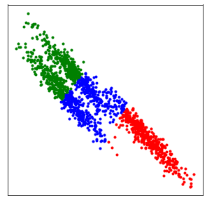

```python
from sklearn.cluster import KMeans

model2_km = KMeans(n_clusters=3).fit(data2_pure)

draw(model2_km, data2_pure)
```

```python
label2=[2, 0, 1]
print("数据集2评价结果：")
cal_E(model2_km.labels_,label2, 3, 2)
```

```
数据集2评价结果：
[[0, 0, 0], [0, 0, 0], [0, 0, 0]]
该聚类结果的可能性矩阵为： [[279, 263, 0], [216, 233, 60], [5, 4, 440]]
[[0.186, 0.17533333333333334, 0.0], [0.144, 0.15533333333333332, 0.04], [0.0033333333333333335, 0.0026666666666666666, 0.29333333333333333]]
[0.36133333333333334, 0.3393333333333333, 0.29933333333333334]
该聚类结果的可能性矩阵中存在0项，无法计算熵！
该聚类结果的纯度为： 0.6346666666666667
```

#### 数据集3

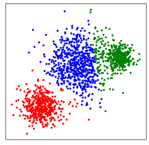

```python
model3_km = KMeans(n_clusters=3).fit(data3_pure)

draw(model3_km, data3_pure)
```

```python
label3=[2, 0, 1]
print("数据集3评价结果：")
cal_E(model3_km.labels_,label3, 3, 3)
```

```
数据集3评价结果：
[[0, 0, 0], [0, 0, 0], [0, 0, 0]]
该聚类结果的可能性矩阵为： [[300, 74, 56], [0, 371, 237], [0, 5, 457]]
[[0.2, 0.04933333333333333, 0.037333333333333336], [0.0, 0.24733333333333332, 0.158], [0.0, 0.0033333333333333335, 0.30466666666666664]]
[0.2866666666666667, 0.4053333333333333, 0.308]
该聚类结果的可能性矩阵中存在0项，无法计算熵！
该聚类结果的纯度为： 0.752
```

#### 数据集4

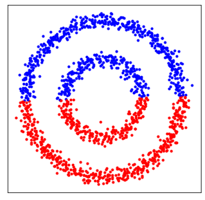

```python
model4_km = KMeans(n_clusters=2).fit(data4_pure)

draw(model4_km, data4_pure)
```

```python
label4=[1, 0]
print("数据集4评价结果：")
cal_E(model4_km.labels_,label4, 2, 4)
```

```
数据集4评价结果：
[[0, 0], [0, 0]]
该聚类结果的可能性矩阵为： [[254, 502], [246, 498]]
[[0.16933333333333334, 0.33466666666666667], [0.164, 0.332]]
[0.504, 0.496]
该聚类结果的熵为： 0.6364981668013017
该聚类结果的纯度为： 0.6666666666666667
```

#### 数据集5

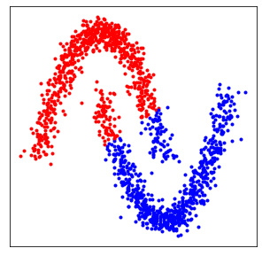

```python
model5_km = KMeans(n_clusters=2).fit(data5_pure)

draw(model5_km, data5_pure)
```

```python
label4=[1, 0]
print("数据集5评价结果：")
cal_E(model5_km.labels_,label5, 2, 5)
```

```
数据集5评价结果：
[[0, 0], [0, 0]]
该聚类结果的可能性矩阵为： [[675, 80], [75, 670]]
[[0.45, 0.05333333333333334], [0.05, 0.44666666666666666]]
[0.5033333333333333, 0.49666666666666665]
该聚类结果的熵为： 0.332308180299824
该聚类结果的纯度为： 0.8966666666666667
```

### 高斯混合模型聚类

**高斯混合模型（Gaussian Mixture Model）**是一种基于概率密度的聚类方法。高斯混合模型试图找到多维高斯模型概率分布的混合表示，从而拟合出任意形状的数据分布。 从聚类策略上来说，高斯混合同样是一种EM模型。

我们使用Scikit-Learn中的**GaussianMixture**对象来完成对各个数据集的聚类：

#### 数据集2

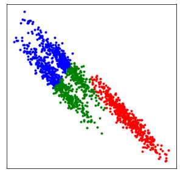

```python
from sklearn.mixture import GaussianMixture

labels_gm_2 = GaussianMixture(n_components=3, covariance_type='full').fit_predict(data2_pure)

fig = plt.figure(figsize = [5,5])
ax = fig.add_subplot(1,1,1)
plt.xticks(())
plt.yticks(())
colors = ['blue','red','green','yellow']

k=0
for i in labels_gm_2:
    plt.scatter(data2_pure[k][0], data2_pure[k][1], c=colors[i], marker='.',label=i)
    k+=1
plt.show()
```

```python
label2 = [0, 2, 1]
cal_E(labels_gm_2,label2, 3, 2)
```

```
[[0, 0, 0], [0, 0, 0], [0, 0, 0]]
该聚类结果的可能性矩阵为： [[279, 272, 0], [212, 228, 6], [9, 0, 494]]
[[0.186, 0.18133333333333335, 0.0], [0.14133333333333334, 0.152, 0.004], [0.006, 0.0, 0.3293333333333333]]
[0.36733333333333335, 0.29733333333333334, 0.3353333333333333]
该聚类结果的可能性矩阵中存在0项，无法计算熵！
该聚类结果的纯度为： 0.6673333333333333
```

#### 数据集3

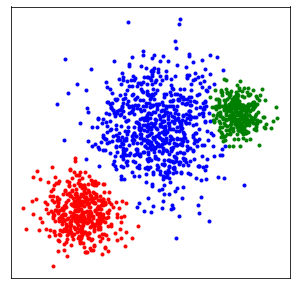

```python
labels_gm_3 = GaussianMixture(n_components=3, covariance_type='full').fit_predict(data3_pure)

fig = plt.figure(figsize = [5,5])
ax = fig.add_subplot(1,1,1)
plt.xticks(())
plt.yticks(())
colors = ['blue','red','green','yellow']

k=0
for i in labels_gm_3:
    plt.scatter(data3_pure[k][0], data3_pure[k][1], c=colors[i], marker='.',label=i)
    k+=1
plt.show()
```

```python
label3 = [2, 0, 1]
cal_E(labels_gm_3,label3, 3, 3)
```

```
[[0, 0, 0], [0, 0, 0], [0, 0, 0]]
该聚类结果的可能性矩阵为： [[296, 15, 12], [4, 435, 289], [0, 0, 449]]
[[0.19733333333333333, 0.01, 0.008], [0.0026666666666666666, 0.29, 0.19266666666666668], [0.0, 0.0, 0.29933333333333334]]
[0.21533333333333335, 0.4853333333333333, 0.29933333333333334]
该聚类结果的可能性矩阵中存在0项，无法计算熵！
该聚类结果的纯度为： 0.7866666666666666
```

#### 数据集4

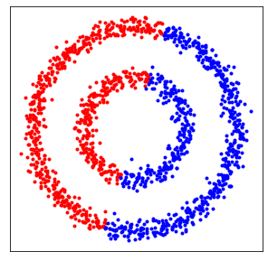

```python
labels_gm_4 = GaussianMixture(n_components=2, covariance_type='full').fit_predict(data4_pure)

fig = plt.figure(figsize = [5,5])
ax = fig.add_subplot(1,1,1)
plt.xticks(())
plt.yticks(())
colors = ['blue','red','green','yellow']

k=0
for i in labels_gm_4:
    plt.scatter(data4_pure[k][0], data4_pure[k][1], c=colors[i], marker='.',label=i)
    k+=1
plt.show()
```

```python
label4 = [0, 1]
cal_E(labels_gm_4,label4, 2, 4)
```

```
[[0, 0], [0, 0]]
该聚类结果的可能性矩阵为： [[251, 504], [249, 496]]
[[0.16733333333333333, 0.336], [0.166, 0.33066666666666666]]
[0.5033333333333334, 0.4966666666666667]
该聚类结果的熵为： 0.6365123904469745
该聚类结果的纯度为： 0.6666666666666667
```

#### 数据集5

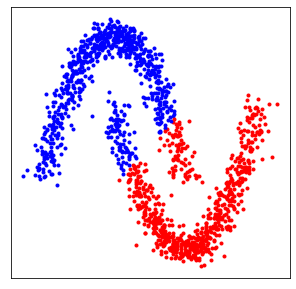

```python
labels_gm_5 = GaussianMixture(n_components=2, covariance_type='full').fit_predict(data5_pure)

fig = plt.figure(figsize = [5,5])
ax = fig.add_subplot(1,1,1)
plt.xticks(())
plt.yticks(())
colors = ['blue','red','green','yellow']

k=0
for i in labels_gm_5:
    plt.scatter(data5_pure[k][0], data5_pure[k][1], c=colors[i], marker='.',label=i)
    k+=1
plt.show()
```

```python
label5 = [0, 1]
cal_E(labels_gm_5,label5, 2, 5)
```

```
[[0, 0], [0, 0]]
该聚类结果的可能性矩阵为： [[669, 91], [81, 659]]
[[0.446, 0.06066666666666667], [0.054, 0.43933333333333335]]
[0.5066666666666667, 0.49333333333333335]
该聚类结果的熵为： 0.35603213666355193
该聚类结果的纯度为： 0.8853333333333333
```

### DBSCAN聚类

**DBSCAN(Density-Based Spatial Clustering of Applications with Noise)**是一种基于密度的聚类方法。 与划分和层次聚类方法不同，它将簇定义为密度相连的点的最大集合，能够把具有足够高密度的区域划分为簇，并可在噪声的空间数据库中发现任意形状的聚类。

我们使用Scikit-Learn中的**DBSCAN**对象来完成对各个数据集的聚类：

#### 数据集2

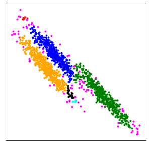

```python
from sklearn.cluster import DBSCAN

model2_dbs = DBSCAN(eps=0.095).fit(data2_pure)
draw(model2_dbs, data2_pure)

# eps 2 0.095
# eps 3 0.2
# eps 4 0.5
# eps 5 0.15
```

```python
label2= [0,3,2]

cal_E(model2_dbs.labels_,label2, 3, 2)
```

```
[[0, 0, 0], [0, 0, 0], [0, 0, 0]]
该聚类结果的可能性矩阵为： [[437, 3, 3], [2, 445, 0], [61, 52, 497]]
[[0.29133333333333333, 0.002, 0.002], [0.0013333333333333333, 0.2966666666666667, 0.0], [0.04066666666666666, 0.034666666666666665, 0.3313333333333333]]
[0.29533333333333334, 0.29800000000000004, 0.4066666666666666]
该聚类结果的可能性矩阵中存在0项，无法计算熵！
该聚类结果的纯度为： 0.9193333333333333
```

#### 数据集3

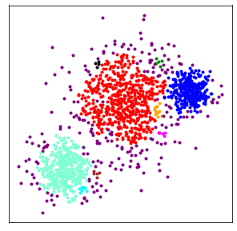

```python
model3_dbs = DBSCAN(eps=0.09).fit(data3_pure)
draw(model3_dbs, data3_pure)
```

```python
label3= [0, 1, 5]

cal_E(model3_dbs.labels_,label3, 3, 3)
```

```
[[0, 0, 0], [0, 0, 0], [0, 0, 0]]
该聚类结果的可能性矩阵为： [[281, 17, 12], [2, 329, 222], [17, 104, 516]]
[[0.18733333333333332, 0.011333333333333334, 0.008], [0.0013333333333333333, 0.21933333333333332, 0.148], [0.011333333333333334, 0.06933333333333333, 0.344]]
[0.20666666666666667, 0.36866666666666664, 0.42466666666666664]
该聚类结果的熵为： 0.5729836296293043
该聚类结果的纯度为： 0.7506666666666666
```

#### 数据集4

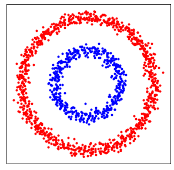

```python
model4_dbs = DBSCAN(eps=0.5).fit(data4_pure)
draw(model4_dbs, data4_pure)
```

```python
label4= [0, 1]

cal_E(model4_dbs.labels_,label4, 2, 4)
```

```
[[0, 0], [0, 0]]
该聚类结果的可能性矩阵为： [[500, 0], [0, 1000]]
[[0.3333333333333333, 0.0], [0.0, 0.6666666666666666]]
[0.3333333333333333, 0.6666666666666666]
该聚类结果的可能性矩阵中存在0项，无法计算熵！
该聚类结果的纯度为： 1.0
```

#### 数据集5

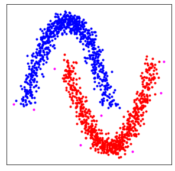

```python
model5_dbs = DBSCAN(eps=0.15).fit(data5_pure)
draw(model5_dbs, data5_pure)
```

```python
label5 = [0, 1]

cal_E(model5_dbs.labels_,label5, 2, 5)
```

```
[[0, 0], [0, 0]]
该聚类结果的可能性矩阵为： [[746, 0], [0, 746]]
[[0.49733333333333335, 0.0], [0.0, 0.49733333333333335]]
[0.49733333333333335, 0.49733333333333335]
该聚类结果的可能性矩阵中存在0项，无法计算熵！
该聚类结果的纯度为： 0.9946666666666667
```

### 聚类算法比较

通过上面的结果我们可以发现，在不同的数据集上，各个聚类算法都表现出了不同的聚类特征。 可以看到，对于非球形数据集（如数据集4和5），前三种聚类方法都表现出了一定的失效，而DBSCAN由于基于密度，使得其在该种数据集上表现十分突出。 而对于样本数差异极大的场景（如数据集3），高斯混合模型表现出了一定的优势（聚类纯度最高）。

综上，各个聚类算法都有其适用场景。面对不同的数据集特征，我们应当选择合适的聚类方法以达到最优的聚类效果。